# R数据分析

# 1 聚类分析

## 1.1 k-means聚类

[k-means in R](https://uc-r.github.io/kmeans_clustering)

```r
#葡萄酒数据
data(wine, package="rattle")
knitr::kable(head(wine))
```

| Type | Alcohol | Malic | Ash | Alcalinity | Magnesium | Phenols | Flavanoids | Nonflavanoids | Proanthocyanins | Color | Hue | Dilution | Proline |
| --- | --- | --- | --- | --- | --- | --- | --- | --- | --- | --- | --- | --- | --- |
| 1 | 14.23 | 1.71 | 2.43 | 15.6 | 127 | 2.80 | 3.06 | 0.28 | 2.29 | 5.64 | 1.04 | 3.92 | 1065 |
| 1 | 13.20 | 1.78 | 2.14 | 11.2 | 100 | 2.65 | 2.76 | 0.26 | 1.28 | 4.38 | 1.05 | 3.40 | 1050 |
| 1 | 13.16 | 2.36 | 2.67 | 18.6 | 101 | 2.80 | 3.24 | 0.30 | 2.81 | 5.68 | 1.03 | 3.17 | 1185 |
| 1 | 14.37 | 1.95 | 2.50 | 16.8 | 113 | 3.85 | 3.49 | 0.24 | 2.18 | 7.80 | 0.86 | 3.45 | 1480 |
| 1 | 13.24 | 2.59 | 2.87 | 21.0 | 118 | 2.80 | 2.69 | 0.39 | 1.82 | 4.32 | 1.04 | 2.93 | 735 |
| 1 | 14.20 | 1.76 | 2.45 | 15.2 | 112 | 3.27 | 3.39 | 0.34 | 1.97 | 6.75 | 1.05 | 2.85 | 1450 |

```r
library(cluster)
set.seed(1234)
fit.pam <- pam(wine[-1], k=3, stand=T)#3个质心
knitr::kable(fit.pam$medoids) #查看质心
```

| Alcohol | Malic | Ash | Alcalinity | Magnesium | Phenols | Flavanoids | Nonflavanoids | Proanthocyanins | Color | Hue | Dilution | Proline |
| --- | --- | --- | --- | --- | --- | --- | --- | --- | --- | --- | --- | --- |
| 13.48 | 1.81 | 2.41 | 20.5 | 100 | 2.70 | 2.98 | 0.26 | 1.86 | 5.1 | 1.04 | 3.47 | 920 |
| 12.25 | 1.73 | 2.12 | 19.0 | 80 | 1.65 | 2.03 | 0.37 | 1.63 | 3.4 | 1.00 | 3.17 | 510 |
| 13.40 | 3.91 | 2.48 | 23.0 | 102 | 1.80 | 0.75 | 0.43 | 1.41 | 7.3 | 0.70 | 1.56 | 750 |

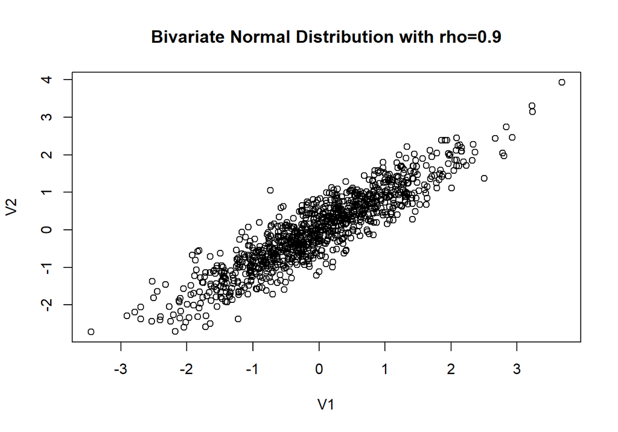

```r
library(fMultivar)
set.seed(1234)
df <- rnorm2d(1000, rho=0.9) #2元正态分布
df <- as.data.frame(df)
plot(df, main="Bivariate Normal Distribution with rho=0.9")

library(ggplot2)
```

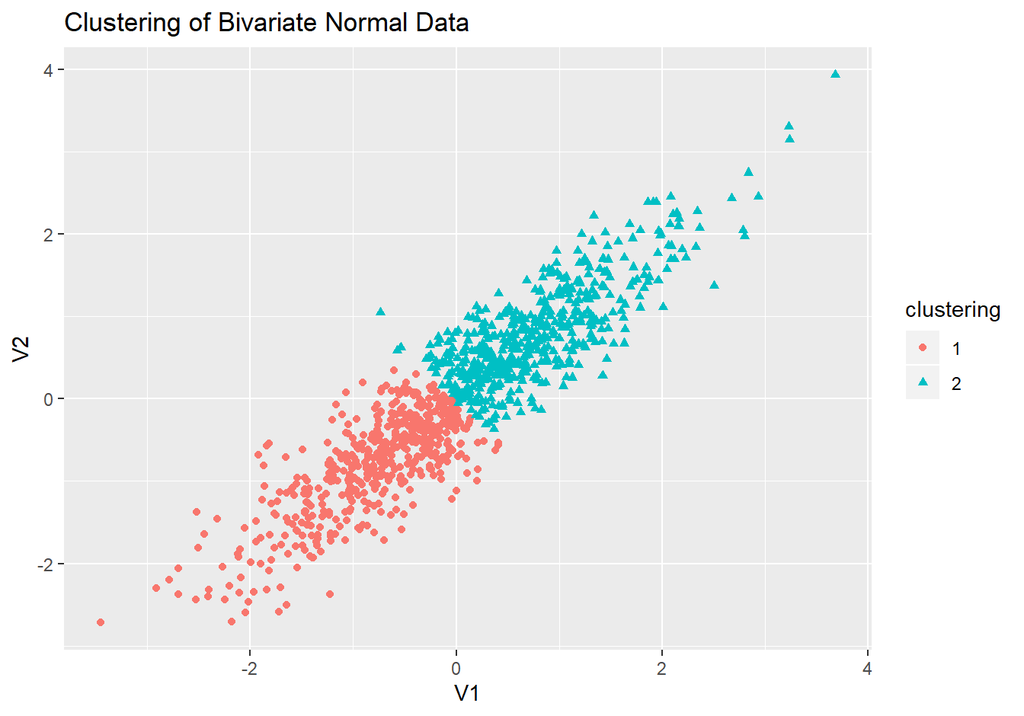

```r
fit <- pam(df, k=2)
df$clustering <- factor(fit$clustering)#输出聚类结果变量
ggplot(data=df, aes(x=V1, y=V2, color=clustering, shape=clustering)) +
geom_point() + ggtitle("Clustering of Bivariate Normal Data")
```

```r
require(graphics)
# a 2-dimensional example
x <- rbind(matrix(rnorm(100, sd = 0.3), ncol = 2),
           matrix(rnorm(100, mean = 1, sd = 0.3), ncol = 2))
colnames(x) <- c("x", "y")
(cl <- kmeans(x, 2))
```

```
K-means clustering with 2 clusters of sizes 47, 53

Cluster means:
             x         y
1  1.004034711 1.0566939
2 -0.006512626 0.0959484

Clustering vector:
  [1] 2 2 2 2 2 2 2 2 2 2 2 2 2 2 2 2 2 2 2 2 2 2 2 2 2 2 2 2 2 2 2 2 2 2 2
 [36] 2 2 2 2 2 2 2 2 2 2 2 2 2 2 2 1 1 1 1 1 1 1 1 1 1 2 1 1 1 1 1 1 1 1 1
 [71] 1 1 1 1 1 1 1 2 1 1 1 1 1 1 1 1 1 1 1 1 1 1 1 1 1 1 1 1 1 2

Within cluster sum of squares by cluster:
[1]  8.515523 12.614531
 (between_SS / total_SS =  69.6 %)

Available components:

[1] "cluster"      "centers"      "totss"        "withinss"
[5] "tot.withinss" "betweenss"    "size"         "iter"
[9] "ifault"
```

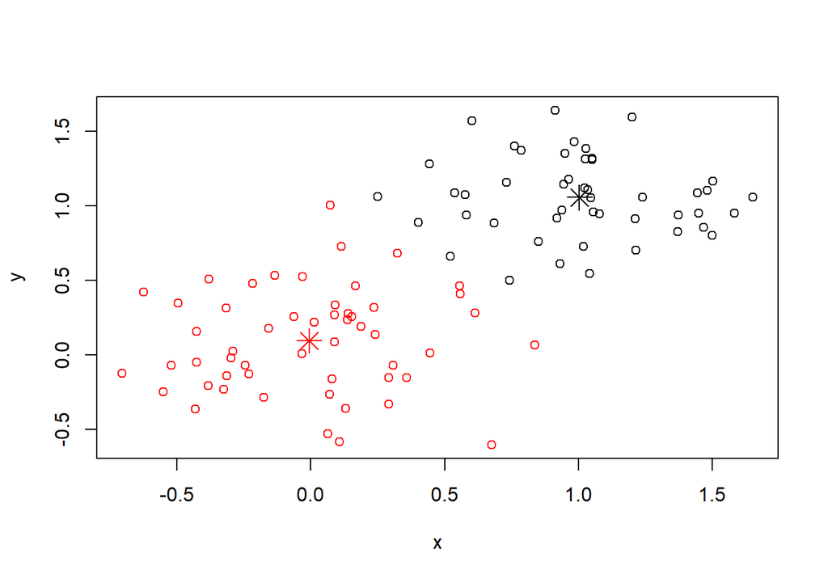

```r
plot(x, col = cl$cluster)
points(cl$centers, col = 1:2, pch = 8, cex = 2)
```

## 1.2 系统聚类

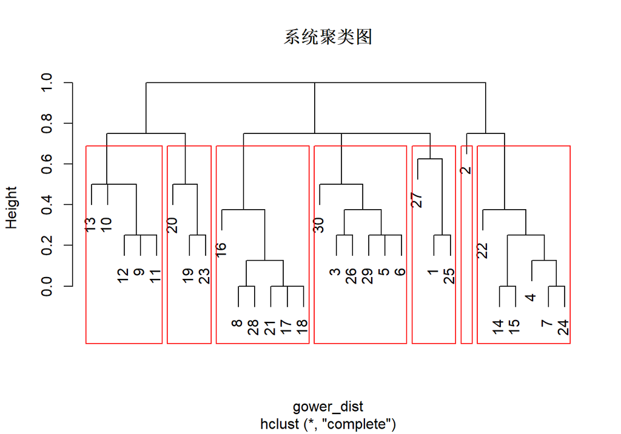

```r
Rclass=read.csv("E:/R_codes/others/Rdclass.csv",header=T)
Rclass1=Rclass[,-c(1,6,7,8)]
rownames(Rclass1)=Rclass$Name
gower_dist<-daisy(Rclass1,metric = "gower")#分类变量的聚类
#summary(gower_dist)
h <- hclust(gower_dist)
plot(h,main = '系统聚类图')
rect.hclust(h, k=7, border = "red")
```

```r
(cn <- cutree(h, k = 7))
```

```
 [1] 1 2 3 4 3 3 4 5 6 6 6 6 6 4 4 5 5 5 7 7 5 4 7 4 1 3 1 5 3 3
```

# 2 词云图

```r
library(wordcloud2)
library(jiebaR)
text <- readLines("E:/R_codes/others/Rkws.csv",encoding = "UTF-8")
text <- text[-1]
freq <- freq(text)
index <- order(-freq[,2])
order2 <- freq[index, ]
wordcloud2(freq,size = 1, color = "random-light")
```

[interactive chart not shown]

```r
#wordcloud2(freq,size = 1, color = "random-light",shape='cardioid')
#wordcloud2(freq,size = 1, color = "random-light",shape='diamond')
```

# 3 主成分分析

```r
#数据:USJudgeRatings
knitr::kable(head(USJudgeRatings))
```

|  | CONT | INTG | DMNR | DILG | CFMG | DECI | PREP | FAMI | ORAL | WRIT | PHYS | RTEN |
| --- | --- | --- | --- | --- | --- | --- | --- | --- | --- | --- | --- | --- |
| AARONSON,L.H. | 5.7 | 7.9 | 7.7 | 7.3 | 7.1 | 7.4 | 7.1 | 7.1 | 7.1 | 7.0 | 8.3 | 7.8 |
| ALEXANDER,J.M. | 6.8 | 8.9 | 8.8 | 8.5 | 7.8 | 8.1 | 8.0 | 8.0 | 7.8 | 7.9 | 8.5 | 8.7 |
| ARMENTANO,A.J. | 7.2 | 8.1 | 7.8 | 7.8 | 7.5 | 7.6 | 7.5 | 7.5 | 7.3 | 7.4 | 7.9 | 7.8 |
| BERDON,R.I. | 6.8 | 8.8 | 8.5 | 8.8 | 8.3 | 8.5 | 8.7 | 8.7 | 8.4 | 8.5 | 8.8 | 8.7 |
| BRACKEN,J.J. | 7.3 | 6.4 | 4.3 | 6.5 | 6.0 | 6.2 | 5.7 | 5.7 | 5.1 | 5.3 | 5.5 | 4.8 |
| BURNS,E.B. | 6.2 | 8.8 | 8.7 | 8.5 | 7.9 | 8.0 | 8.1 | 8.0 | 8.0 | 8.0 | 8.6 | 8.6 |

```r
library(psych)
fa.parallel(USJudgeRatings[,-1], fa="pc", n.iter=100,
show.legend=F, main="碎石图")
```

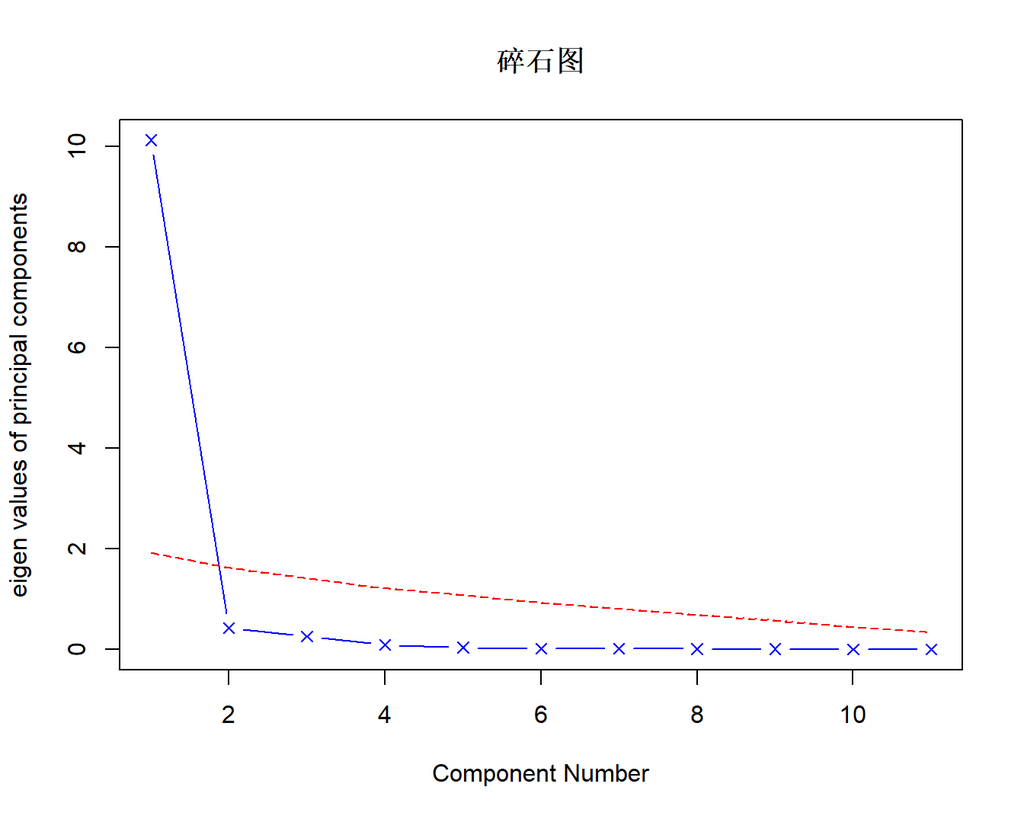

```
Parallel analysis suggests that the number of factors =  NA  and the number of components =  1
```

```r
pc <- principal(USJudgeRatings[,-1], nfactors=1, rotate="varimax", score=T) #方差极大旋转
pc
```

```
Principal Components Analysis
Call: principal(r = USJudgeRatings[, -1], nfactors = 1, rotate = "varimax",
    scores = T)
Standardized loadings (pattern matrix) based upon correlation matrix
      PC1   h2     u2 com
INTG 0.92 0.84 0.1565   1
DMNR 0.91 0.83 0.1663   1
DILG 0.97 0.94 0.0613   1
CFMG 0.96 0.93 0.0720   1
DECI 0.96 0.92 0.0763   1
PREP 0.98 0.97 0.0299   1
FAMI 0.98 0.95 0.0469   1
ORAL 1.00 0.99 0.0091   1
WRIT 0.99 0.98 0.0196   1
PHYS 0.89 0.80 0.2013   1
RTEN 0.99 0.97 0.0275   1

                 PC1
SS loadings    10.13
Proportion Var  0.92

Mean item complexity =  1
Test of the hypothesis that 1 component is sufficient.

The root mean square of the residuals (RMSR) is  0.04
 with the empirical chi square  6.21  with prob <  1

Fit based upon off diagonal values = 1
```

```r
USJudgeRatings$score <- pc$scores
knitr::kable(head(USJudgeRatings$score))
```

|  | PC1 |
| --- | --- |
| AARONSON,L.H. | -0.1857981 |
| ALEXANDER,J.M. | 0.7469865 |
| ARMENTANO,A.J. | 0.0704772 |
| BERDON,R.I. | 1.1358765 |
| BRACKEN,J.J. | -2.1586211 |
| BURNS,E.B. | 0.7669406 |

# 4 市场人群细分

- CHAID算法
  - 卡方自动交互检测器
- Latent Class
- Canonical Correlation (典型相关分析)
  - 可以做多组变量(连续、离散）的分析
  - 之后做聚类
  - 出来之后的维度类似于因子，思路和因子分析相差不大
  - 权重和loading
  - 保存对象得分，得出连续因子
- 最后做系统聚类，最小聚类数，最大聚类数。最好使用`ward`方法
- 1000样本量尽量分4-5群
- 说服自己、说服客服
- 最后做判别分析

# 5 机器学习笔记

- 机器学习不能解决[不完全信息动态博弈](https://mp.weixin.qq.com/s/Yz7gBKZK9mclVMl1A6hP7w)。
- 深度学习能够解决简单的模式识别问题。

# 6 计量经济学

教材：[Introduction to Econometrics with R](https://www.econometrics-with-r.org/index.html)

## 6.1 断点回归

- Regression Discontinuity Design

```r
library(dplyr)
library(magrittr)
library(MASS)
library(rdd)
library(modelr)
library(cowplot)
set.seed(1)
n <- 10 ^ 3
mu <- matrix(c(0, 0))
rho <- 0.5
sigma1 <- 0.5
sigma2 <- 2
Sigma <- matrix(c(sigma1 ^ 2,
rho * sigma1 * sigma2,
rho * sigma1 * sigma2,
sigma2 ^ 2),
c(2, 2))
simulatedXandC <- mvrnorm(n = n, mu = mu, Sigma = Sigma)
simulatedError <- rnorm(n = n)
simulatedZ <- round(runif(n))
group <- round(runif(n))
df <- data.frame(X = simulatedXandC[, 1],
C = simulatedXandC[, 2],
error = simulatedError)
df %<>%
mutate(Y = 10 + 1 * X + 5 * C + error)
fit <- lm(Y ~ X,df)
summary(fit)
```

```
Call:
lm(formula = Y ~ X, data = df)

Residuals:
    Min      1Q  Median      3Q     Max
-28.343  -6.053   0.328   5.787  35.597

Coefficients:
            Estimate Std. Error t value Pr(>|t|)
(Intercept)   9.8560     0.2884   34.18   <2e-16 ***
X            10.8872     0.5571   19.54   <2e-16 ***
---
Signif. codes:  0 '***' 0.001 '**' 0.01 '*' 0.05 '.' 0.1 ' ' 1

Residual standard error: 9.118 on 998 degrees of freedom
Multiple R-squared:  0.2767,    Adjusted R-squared:  0.276
F-statistic: 381.9 on 1 and 998 DF,  p-value: < 2.2e-16
```

```r
fit <- lm(Y ~ X + C,df)
summary(fit)
```

```
Call:
lm(formula = Y ~ X + C, data = df)

Residuals:
    Min      1Q  Median      3Q     Max
-3.6151 -0.6564 -0.0223  0.6815  2.8132

Coefficients:
            Estimate Std. Error t value Pr(>|t|)
(Intercept) 10.01624    0.03260  307.27   <2e-16 ***
X            0.95233    0.07242   13.15   <2e-16 ***
C            5.03078    0.01812  277.71   <2e-16 ***
---
Signif. codes:  0 '***' 0.001 '**' 0.01 '*' 0.05 '.' 0.1 ' ' 1

Residual standard error: 1.031 on 997 degrees of freedom
Multiple R-squared:  0.9908,    Adjusted R-squared:  0.9908
F-statistic: 5.351e+04 on 2 and 997 DF,  p-value: < 2.2e-16
```

```r
df <- data.frame(X = simulatedXandC[, 1],
C = simulatedXandC[, 2],
T = (simulatedXandC[, 1] > 0),
error = simulatedError)
df %<>%
mutate(Y = 10 + X ^ 3 + 5 * T + 1 * C + error)
fit <- RDestimate(Y ~ X,df)
summary(fit)
```

```
Call:
RDestimate(formula = Y ~ X, data = df)

Type:
sharp

Estimates:
           Bandwidth  Observations  Estimate  Std. Error  z value
LATE       0.4093     572           4.940     0.3750      13.173
Half-BW    0.2046     299           4.943     0.5122       9.649
Double-BW  0.8186     883           5.014     0.2781      18.029
           Pr(>|z|)
LATE       1.255e-39  ***
Half-BW    4.959e-22  ***
Double-BW  1.158e-72  ***
---
Signif. codes:  0 '***' 0.001 '**' 0.01 '*' 0.05 '.' 0.1 ' ' 1

F-statistics:
           F      Num. DoF  Denom. DoF  p
LATE       340.8  3         568         0
Half-BW    164.0  3         295         0
Double-BW  622.0  3         879         0
```

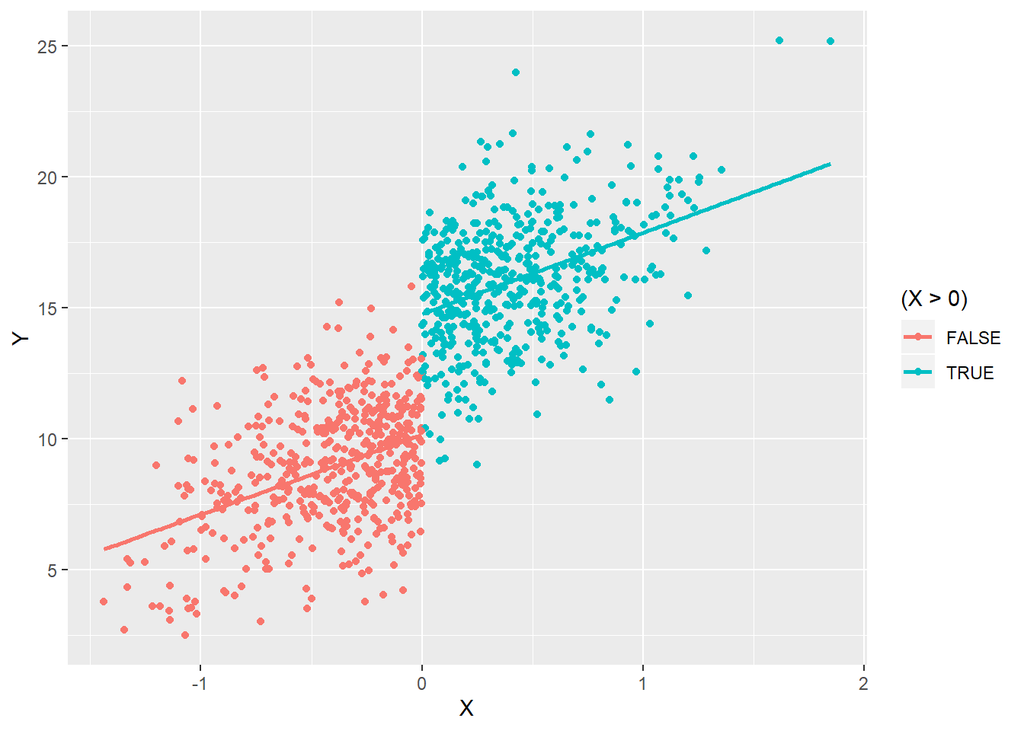

```r
ggplot(df,aes(X,Y,color = (X > 0))) +
geom_point() +
geom_smooth(method=lm,se = F)
```

## 6.2 双重差分

- Difference-in-Differences

```r
df <- data.frame(time = 10 * round(runif(n), 1) - 5,
treatment = group,
error = simulatedError)

df %<>%
mutate(Y = 1 - time + 5 * treatment + 7 * (time >= 0) * treatment + error)
fit <- lm(Y ~ time + treatment + I((time >= 0) * treatment), data = df)
summary(fit)
```

```
Call:
lm(formula = Y ~ time + treatment + I((time >= 0) * treatment),
    data = df)

Residuals:
    Min      1Q  Median      3Q     Max
-3.5732 -0.6357 -0.0390  0.7135  2.8892

Coefficients:
                           Estimate Std. Error t value Pr(>|t|)
(Intercept)                 1.00244    0.04505   22.25   <2e-16 ***
time                       -0.96524    0.01403  -68.80   <2e-16 ***
treatment                   5.10952    0.09284   55.03   <2e-16 ***
I((time >= 0) * treatment)  6.85218    0.11881   57.67   <2e-16 ***
---
Signif. codes:  0 '***' 0.001 '**' 0.01 '*' 0.05 '.' 0.1 ' ' 1

Residual standard error: 1.029 on 996 degrees of freedom
Multiple R-squared:  0.9601,    Adjusted R-squared:   0.96
F-statistic:  7985 on 3 and 996 DF,  p-value: < 2.2e-16
```

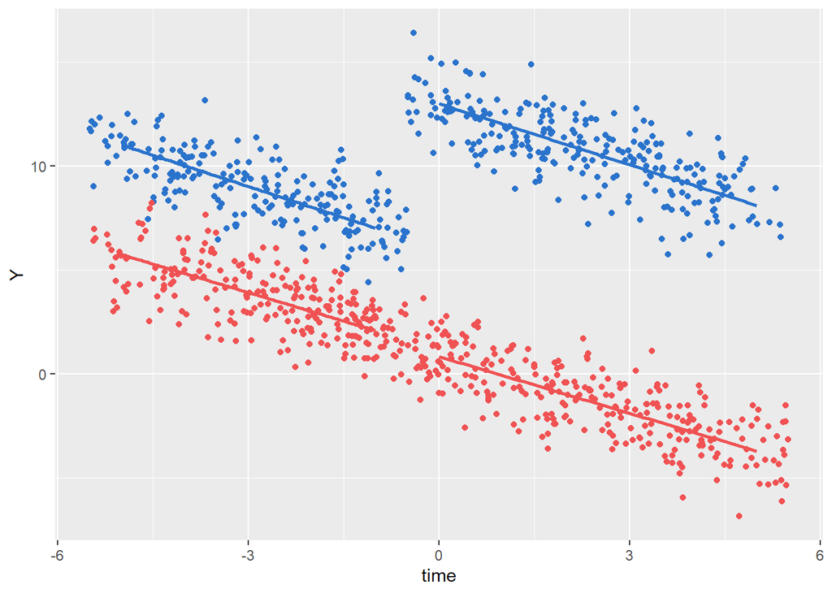

```r
dfMean <- df %>%
group_by(time, treatment) %>%
summarise(Y = mean(Y))

ggplot(df, aes(time,Y, color = factor(treatment + 2 * (time >= 0)))) +
geom_jitter(width=0.5,height=1) +
geom_smooth(method = lm,se = F) +
theme(legend.position = "none") +
scale_color_manual(values = c("#F05253", "#2A73CC", "#F05253", "#2A73CC"))
```

## 6.3 固定效应模型

- Fixed Effects Regression

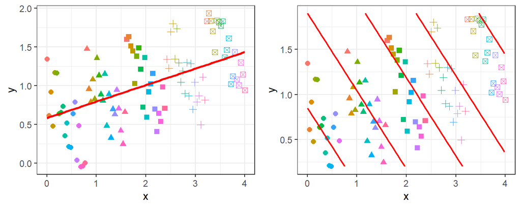

Figure 6.1: $x$为自变量，$y$为因变量。形状代表不同个体，颜色代表多个调查年份。左图：合并回归(Pooled OLS)，将所有点视为一个个体。右图：组内估计量(within-group)，控制个体，观测每个个体随调查时间的变化。

```r
set.seed(222)
x <- seq(0,4,length = 100)
y <- -x + jitter(rep(1:5, each = 20), 2)
z <-  rep(1:5, each = 20) %>% as.factor()
dt <- data.frame(x,y,z) %>%
  group_by(z) %>%
  mutate(c=rep(1:20,length = 20),
         year=as.factor(c))
#View(dt)
plta <- ggplot(dt, aes(x, y)) +
  geom_point(aes(color=year,shape=z),size=2) +
  geom_smooth(method='lm',se=F,color='red') +
  theme_bw() +
  theme(legend.position = 'none')

moda <- lm(y ~ x + z,dt)
grid <- dt %>%
data_grid(x,z) %>%
gather_predictions(moda)

pltb <- ggplot(dt, aes(x, y)) +
  geom_point(aes(color=year,shape=z),size=2) +
  geom_line(data=grid,aes(pred,x,group=z),
            size=0.75,color='red') +
  ylim(0.2,1.9)+
  xlim(0,4)+
  theme_bw() +
  theme(legend.position = 'none')

plot_grid(plta,pltb,ncol = 2)
```

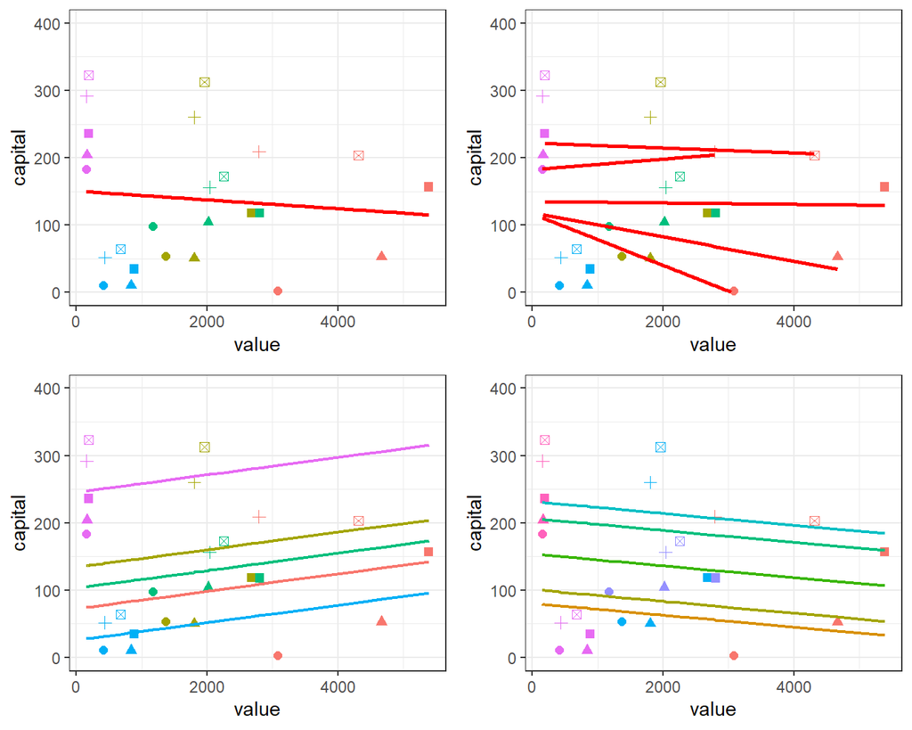

Figure 6.2: 左上：线性回归。右上：分年份拟合。左下：固定效应。右下：时间固定效应。

```r
data('Grunfeld', package = 'plm')

Grunfeld <- Grunfeld %>%
  filter(year<1940,firm<6) %>%
  mutate(year=as.factor(year),
         firm=as.factor(firm))

plta <- ggplot(Grunfeld, aes(value,capital)) +
  geom_point(aes(col=firm,shape=year),size=2) +
  geom_smooth(method='lm',se=F,color='red') +
  theme_bw() +
  theme(legend.position = 'none')+
  ylim(0,400)

pltb <- ggplot(Grunfeld, aes(value,capital,group=year)) +
  geom_point(aes(col=firm,shape=year),size=2) +
  geom_smooth(method='lm',se=F,color='red') +
  theme_bw() +
  theme(legend.position = 'none')+
  ylim(0,400)

moda <- lm(capital ~ value + firm,Grunfeld)
grid <- Grunfeld %>%
data_grid(value,firm) %>%
gather_predictions(moda)

pltc <- ggplot(Grunfeld, aes(value,capital)) +
  geom_point(aes(col=firm,shape=year),size=2) +
  geom_line(data=grid,aes(value,pred,
                          color=firm,
                          group=firm),size=0.75) +
  theme_bw() +
  theme(legend.position = 'none')+
  ylim(0,400)

modc <- lm(capital ~ value + year,Grunfeld)
grid <- Grunfeld %>%
data_grid(value,year) %>%
gather_predictions(modc)

pltd <- ggplot(Grunfeld, aes(value,capital)) +
  geom_point(aes(col=firm,shape=year),size=2) +
  geom_line(data=grid,aes(value,pred,
                          color=year,
                          group=year),size=0.75) +
  theme_bw() +
  theme(legend.position = 'none')+
  ylim(0,400)

plot_grid(plta,pltb,pltc,pltd,ncol = 2)
```

```r
library(plm)
ols <- lm(inv ~ value + capital,
          data = Grunfeld)

fe <- plm(inv ~ value + capital,
          data = Grunfeld, model = 'within',
          effect='individual')

tw <- plm(inv ~ value + capital,
          data = Grunfeld, model = 'within', effect = 'twoways')

stargazer::stargazer(ols,fe,tw,
          title='回归结果',
          dep.var.caption=' ',
          dep.var.labels=' ',
          align=T,
          type='html',column.labels=c('线性回归','组内估计','双重固定'),
          keep.stat=c('n','rsq','ll'))
```

**回归结果**

|  | *OLS* | *panel* |  |
| --- | --- | --- | --- |
|  |  | *linear* |  |
|  | 线性回归 | 组内估计 | 双重固定 |
|  | (1) | (2) | (3) |
| value | 0.075*** | 0.068*** | 0.049** |
|  | (0.014) | (0.014) | (0.021) |
| capital | 0.016 | -0.273** | -0.449* |
|  | (0.207) | (0.111) | (0.216) |
| Constant | 26.792 |  |  |
|  | (44.024) |  |  |
| Observations | 25 | 25 | 25 |
| R<sup>2</sup> | 0.577 | 0.608 | 0.403 |
| *Note:* | p<0.1; p<0.05; p<0.01 |  |  |

## 6.4 工具变量

- Instrumental Variables

```r
df <- data.frame(Z = simulatedZ,
X = simulatedXandC[, 1] + simulatedZ,
C = simulatedXandC[, 2],
error = simulatedError)
df %<>%
mutate(Y = 10 + 1.0 * X - 2 * C + error)

#Naive regression produces biased estimates
fit1 <- lm(Y ~ X,df)
summary(fit, vcov = sandwich)
```

```
Call:
lm(formula = Y ~ time + treatment + I((time >= 0) * treatment),
    data = df)

Residuals:
    Min      1Q  Median      3Q     Max
-3.5732 -0.6357 -0.0390  0.7135  2.8892

Coefficients:
                           Estimate Std. Error t value Pr(>|t|)
(Intercept)                 1.00244    0.04505   22.25   <2e-16 ***
time                       -0.96524    0.01403  -68.80   <2e-16 ***
treatment                   5.10952    0.09284   55.03   <2e-16 ***
I((time >= 0) * treatment)  6.85218    0.11881   57.67   <2e-16 ***
---
Signif. codes:  0 '***' 0.001 '**' 0.01 '*' 0.05 '.' 0.1 ' ' 1

Residual standard error: 1.029 on 996 degrees of freedom
Multiple R-squared:  0.9601,    Adjusted R-squared:   0.96
F-statistic:  7985 on 3 and 996 DF,  p-value: < 2.2e-16
```

```r
#IV recovers the underlying model
fit2 <- ivreg(Y ~ X | Z, data = df)
summary(fit, vcov = sandwich, df = Inf, diagnostics = T)
```

```
Call:
lm(formula = Y ~ time + treatment + I((time >= 0) * treatment),
    data = df)

Residuals:
    Min      1Q  Median      3Q     Max
-3.5732 -0.6357 -0.0390  0.7135  2.8892

Coefficients:
                           Estimate Std. Error t value Pr(>|t|)
(Intercept)                 1.00244    0.04505   22.25   <2e-16 ***
time                       -0.96524    0.01403  -68.80   <2e-16 ***
treatment                   5.10952    0.09284   55.03   <2e-16 ***
I((time >= 0) * treatment)  6.85218    0.11881   57.67   <2e-16 ***
---
Signif. codes:  0 '***' 0.001 '**' 0.01 '*' 0.05 '.' 0.1 ' ' 1

Residual standard error: 1.029 on 996 degrees of freedom
Multiple R-squared:  0.9601,    Adjusted R-squared:   0.96
F-statistic:  7985 on 3 and 996 DF,  p-value: < 2.2e-16
```

[output not shown]

# 7 LASSO回归

- OLS:
  $$\hat \beta = argmin_{{\beta \in {R^d}}}||Y - X\beta |{|^2} = {({X^T}X)^{ - 1}}{X^T}Y$$
- 惩罚似然函数的一般形式：
  $$\hat{\beta} = argmin_{\beta \in R^d}(||Y - X\beta||^2 + P_{\lambda}(|\beta|))$$

其中，惩罚项$P_{\lambda}(|\beta|) = \lambda \sum_{j = 1}^{d}|\beta_j|^m,m>=0$。当$m=1$时，得到$L_1$惩罚项(LASSO回归)，当$m=2$时，得到$L_2$惩罚项(岭回归)。

$$\hat{\beta_{Lasso}} = arg min_{\beta \in R^d}||Y - X\beta||^2 +\lambda \sum_{j = 1}^{d}|\beta_j|$$

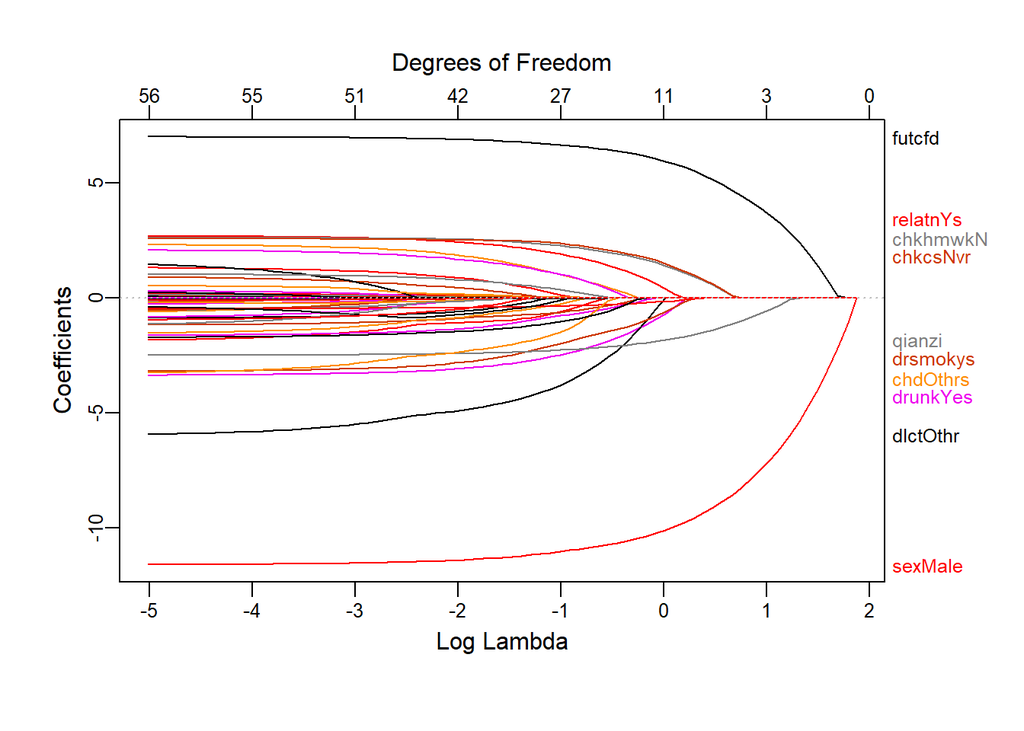

```r
library(haven)
library(tidyr)
library(plotmo)
library(glmnet)
library(readr)
`%>%` <- magrittr::`%>%`

ceps <- read_csv("C:/Users/xsong/Desktop/table/ceps.imputed.csv")

ceps <- na.omit(ceps)

x_train <- model.matrix(sdtotal ~ schids + sex + onechi +  maedu +  faedu + drunk + qurel + relation +  desk + net + dialect + chkhmwk + chkcouse + classtm + clpre + revitm + subject + know + drsmok + commhr + schtype + schcsrm +  comno +  bknum + buget + eduqua + fight + brkpb + smok +  drink +  teainc + money + clfee + qianzi + lifetm +  dial +  chidia +  futcfd +  huko + eduy +  dangy + houspro,ceps)[,-1]

y_train <- ceps$sdtotal %>%
  unlist() %>%
  as.numeric()

lasso_mod <- glmnet(x_train,y_train,alpha = 1)


plot_glmnet(lasso_mod,xvar='lambda',label=10)
```

```r
cvfit <- cv.glmnet(x_train,
                   y_train,
                   alpha = 1)
cvfit$lambda.min
```

```
[1] 0.1086777
```

```r
cvfit$lambda.1se
```

```
[1] 0.5799802
```

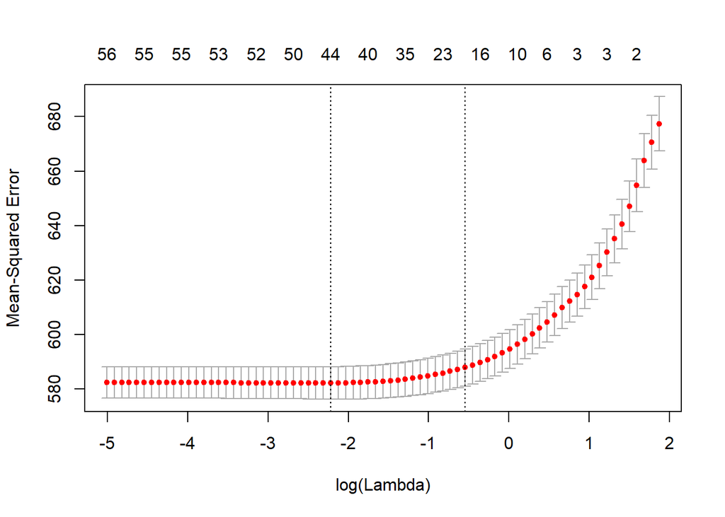

```r
plot(cvfit)
```

# 8 XGBOOST

- 在变量的层面并行计算
- 可以进行正则化收缩

参数：

| booster | 基学习器 | 线性回归：gblinear 决策树：gbtree |
| --- | --- | --- |
| eta | 学习率 |  |
| gamma | 最小伽马损失减少量 |  |
| max_depth | 每棵树的最大深度。默认为6 |  |
| objective | 任务参数。 | reg:squarederror 回归 logistic回归 binary:logistic 输出logistic概率 rank:pairwise 排序 num_class 多分类 |
| nrounds | 最大boost迭代数 | 自变量和因变量关系越复杂nrounds需要越大 |

```r
library(xgboost)
library(rpart.plot)
data(agaricus.train, package='xgboost')
data(agaricus.test, package='xgboost')
train <- agaricus.train
test <- agaricus.test
bst <- xgboost(data = train$data, label = train$label, max_depth = 2, eta = 1,nrounds = 2,verbose = 3, objective = "binary:logistic")
importance_matrix <- xgb.importance(model = bst)
xgb.plot.importance(importance_matrix = importance_matrix)
```

[figure not shown]

```r
xgb.dump(bst, with_stats = T)
```

```
 [1] "booster[0]"
 [2] "0:[f28<-9.53674316e-007] yes=1,no=2,missing=1,gain=4000.53101,cover=1628.25"
 [3] "1:[f55<-9.53674316e-007] yes=3,no=4,missing=3,gain=1158.21204,cover=924.5"
 [4] "3:leaf=1.71217716,cover=812"
 [5] "4:leaf=-1.70044053,cover=112.5"
 [6] "2:[f108<-9.53674316e-007] yes=5,no=6,missing=5,gain=198.173828,cover=703.75"
 [7] "5:leaf=-1.94070864,cover=690.5"
 [8] "6:leaf=1.85964918,cover=13.25"
 [9] "booster[1]"
[10] "0:[f59<-9.53674316e-007] yes=1,no=2,missing=1,gain=832.545044,cover=788.852051"
[11] "1:[f28<-9.53674316e-007] yes=3,no=4,missing=3,gain=569.725098,cover=768.389709"
[12] "3:leaf=0.78471756,cover=458.936859"
[13] "4:leaf=-0.968530357,cover=309.45282"
[14] "2:leaf=-6.23624468,cover=20.462389"
```

```r
#xgb.plot.tree(model = bst,trees=0,show_node_id=T)

pred <- predict(bst, test$data)
```

```r
logregobj <- function(preds, dtrain) {
labels <- getinfo(dtrain, "label")
preds <- 1/(1 + exp(-preds))
grad <- preds - labels
hess <- preds * (1 - preds)
return(list(grad = grad, hess = hess))
}
evalerror <- function(preds, dtrain) {
labels <- getinfo(dtrain, "label")
err <- sqrt(mean((preds-labels)^2))
return(list(metric = "MSE", value = err))
}

dtrain <- xgb.DMatrix(train$data, label = train$label)

dtest <- xgb.DMatrix(test$data, label = test$label)
watchlist <- list(eval = dtest, train = dtrain)
param <- list(max_depth = 2, eta = 1, silent = 1)
bst <- xgb.train(param, dtrain, nrounds = 2, watchlist, logregobj, evalerror, maximize = FALSE)
```

# 9 对数线性模型

```r
## http://ww2.coastal.edu/kingw/statistics/R-tutorials/loglin.html

data(Titanic)
View(Titanic)
dimnames(Titanic)
margin.table(Titanic, c(2,4))

### begin copying script here
likelihood.test = function(x) {
  nrows = dim(x)[1]                      # no. of rows in contingency table
  ncols = dim(x)[2]                      # no. of cols in contingency table
  chi.out = chisq.test(x,correct=F)      # do a Pearson chi square test
  table = chi.out[[6]]                   # get the OFs
  ratios = chi.out[[6]]/chi.out[[7]]     # calculate OF/EF ratios
  sum = 0                                # storage for the test statistic
  for (i in 1:nrows) {
    for (j in 1:ncols) {
      sum = sum + table[i,j]*log(ratios[i,j])
    }
  }
  sum = 2 * sum                          # the likelihood ratio chi square
  df = chi.out[[2]]                      # degrees of freedom
  p = 1 - pchisq(sum,df)                 # p-value
  out = c(sum, df, p, chi.out[[1]])      # the output vector
  names(out) = c("LR-chisq","df","p-value","Pears-chisq")
  round(out,4)                           # done!
}
### end copying script here and paste into R Console
sex.survived = margin.table(Titanic, c(2,4))
summary(Titanic)
library(MASS)
k <- loglm( ~ Sex + Survived, data=sex.survived)
k
summary(k)

loglm(~ Class + Sex + Age + Survived, data=Titanic)

loglm(~ Class * Sex * Age * Survived, data=Titanic)

loglm(~ Class * Sex * Age * Survived - Class:Sex:Age:Survived, data=Titanic)

loglm(formula = ~Class + Sex + Age + Survived +
        Class:Sex + Class:Age +
        Sex:Age + Class:Survived + Age:Survived + Class:Sex:Age +
        Class:Age:Survived, data=Titanic)
```

# 10 有限混合模型

`flexmix`

```r
library(flexmix)
data("NPreg", package = "flexmix")
## mixture of two linear regression models. Note that control parameters
## can be specified as named list and abbreviated if unique.
ex1 <- flexmix(yn ~ x + I(x^2), data=NPreg, k=2,
               control=list(verb=5, iter=100))
```

```
Classification: weighted
   5 Log-likelihood :    -722.6931
  10 Log-likelihood :    -661.8846
  15 Log-likelihood :    -642.5456
  16 Log-likelihood :    -642.5453
```

```r
ex1
```

```
Call:
flexmix(formula = yn ~ x + I(x^2), data = NPreg, k = 2, control = list(verb = 5,
    iter = 100))

Cluster sizes:
  1   2
100 100

convergence after 16 iterations
```

```r
summary(ex1)
```

```
Call:
flexmix(formula = yn ~ x + I(x^2), data = NPreg, k = 2, control = list(verb = 5,
    iter = 100))

       prior size post>0 ratio
Comp.1 0.494  100    145 0.690
Comp.2 0.506  100    141 0.709

'log Lik.' -642.5453 (df=9)
AIC: 1303.091   BIC: 1332.775
```

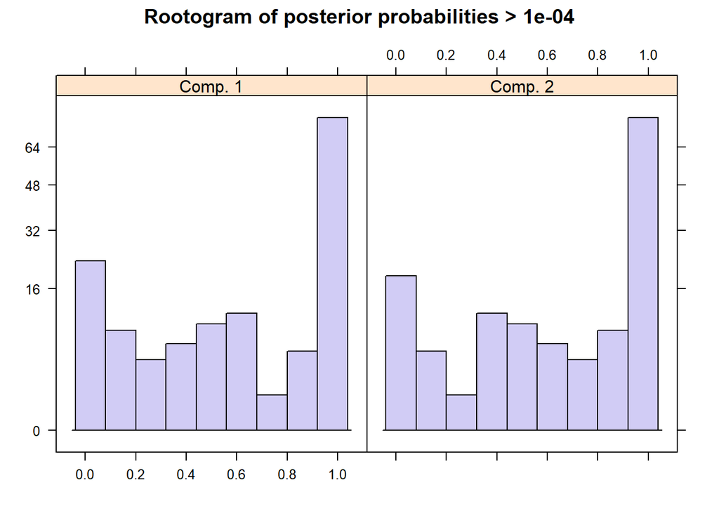

```r
plot(ex1)
```

# 11 文本分析笔记

中山大学

- $$文本作为数据$$

文本比较 微博情绪研究 情感分析

网络论坛：天涯、凯迪社区、

媒体数据库：人民日报、纽约时报

网上社区：百度贴吧

中国裁判文书网：法学、犯罪学

- 特征

多种来源  
非结构化  
长尾分布  
词语之间复杂微妙的关系  
词语模糊性和情景敏感性

- $$文本数据与外部数据结合$$

微博情绪文本、股票市场  
重大事件与重大事件的关系  
政策文本与地方实际表现

- 机器学习

无监督学习（文本聚类、主题模型）  
**半监督学习**（随机森林、朴素贝叶斯）

- 新进展

词向量模型（`Word2vec`）  
循环神经网络（`RNN`）

- 清理文本

删除停词  
大小写  
删除  
提取词干  
去除标点符号  
去除非字符符号  
提取标题、作者、日历、电子邮箱、地址等  
分词

包  
`text2vec` `e1701` `tm` `Snomba`

- 词汇语义变迁研究  
  特定类型词汇库的完善  
  实体关系或网络构建  
  文本相似性计算  
  情感分析

# 12 常见统计检验

```r
t.test(extra ~ group,sleep)
```

```
    Welch Two Sample t-test

data:  extra by group
t = -1.8608, df = 17.776, p-value = 0.07939
alternative hypothesis: true difference in means is not equal to 0
95 percent confidence interval:
 -3.3654832  0.2054832
sample estimates:
mean in group 1 mean in group 2
           0.75            2.33
```

```r
wilcox.test(extra ~ group,sleep)
```

```
    Wilcoxon rank sum test with continuity correction

data:  extra by group
W = 25.5, p-value = 0.06933
alternative hypothesis: true location shift is not equal to 0
```

```r
M <- as.table(rbind(c(762, 327, 468), c(484, 239, 477)))
dimnames(M) <- list(gender = c("F", "M"),
                    party = c("Democrat","Independent", "Republican"))
(Xsq <- chisq.test(M))  # Prints test summary
```

```
    Pearson's Chi-squared test

data:  M
X-squared = 30.07, df = 2, p-value = 2.954e-07
```

```r
Xsq$observed   # observed counts (same as M)
```

```
      party
gender Democrat Independent Republican
     F      762         327        468
     M      484         239        477
```

```r
Xsq$expected   # expected counts under the null
```

```
      party
gender Democrat Independent Republican
     F 703.6714    319.6453   533.6834
     M 542.3286    246.3547   411.3166
```

```r
Xsq$residuals  # Pearson residuals
```

```
      party
gender   Democrat Independent Republican
     F  2.1988558   0.4113702 -2.8432397
     M -2.5046695  -0.4685829  3.2386734
```

```r
Xsq$stdres     # standardized residuals
```

```
      party
gender   Democrat Independent Republican
     F  4.5020535   0.6994517 -5.3159455
     M -4.5020535  -0.6994517  5.3159455
```

# 13 时间序列分析

[使用`tsibble`](https://mp.weixin.qq.com/s/EjCTFsvzYV7o5Q-V3GmBRA)

```r
library(tsibble)
USAccDeaths
```

```
       Jan   Feb   Mar   Apr   May   Jun   Jul   Aug   Sep   Oct   Nov
1973  9007  8106  8928  9137 10017 10826 11317 10744  9713  9938  9161
1974  7750  6981  8038  8422  8714  9512 10120  9823  8743  9129  8710
1975  8162  7306  8124  7870  9387  9556 10093  9620  8285  8466  8160
1976  7717  7461  7767  7925  8623  8945 10078  9179  8037  8488  7874
1977  7792  6957  7726  8106  8890  9299 10625  9302  8314  8850  8265
1978  7836  6892  7791  8192  9115  9434 10484  9827  9110  9070  8633
       Dec
1973  8927
1974  8680
1975  8034
1976  8647
1977  8796
1978  9240
```

```r
USAccDeaths %>% as_tsibble() %>% head()
```

```
# A tsibble: 6 x 2 [1M]
     index value
     <mth> <dbl>
1 1973 1月  9007
2 1973 2月  8106
3 1973 3月  8928
4 1973 4月  9137
5 1973 5月 10017
6 1973 6月 10826
```

```r
tourism %>%
  filter(Purpose == "Holiday") %>%
  group_by(State) %>%
  summarise(Trips = sum(Trips)) %>%
  head()
```

```
# A tsibble: 6 x 3 [1Q]
# Key:       State [1]
  State Quarter Trips
  <chr>   <qtr> <dbl>
1 ACT   1998 Q1  196.
2 ACT   1998 Q2  127.
3 ACT   1998 Q3  111.
4 ACT   1998 Q4  170.
5 ACT   1999 Q1  108.
6 ACT   1999 Q2  125.
```

```r
tourism %>%
  mutate(Year = lubridate::year(Quarter)) %>%
  index_by(Year) %>%
  group_by(Region, State, Purpose) %>%
  summarise(Trips = sum(Trips)) %>%
  ungroup()
```

```
# A tsibble: 6,080 x 5 [1Y]
# Key:       Region, State, Purpose [304]
   Region   State           Purpose   Year Trips
   <chr>    <chr>           <chr>    <dbl> <dbl>
 1 Adelaide South Australia Business  1998  538.
 2 Adelaide South Australia Business  1999  641.
 3 Adelaide South Australia Business  2000  787.
 4 Adelaide South Australia Business  2001  608.
 5 Adelaide South Australia Business  2002  697.
 6 Adelaide South Australia Business  2003  690.
 7 Adelaide South Australia Business  2004  734.
 8 Adelaide South Australia Business  2005  490.
 9 Adelaide South Australia Business  2006  568.
10 Adelaide South Australia Business  2007  584.
# ... with 6,070 more rows
```

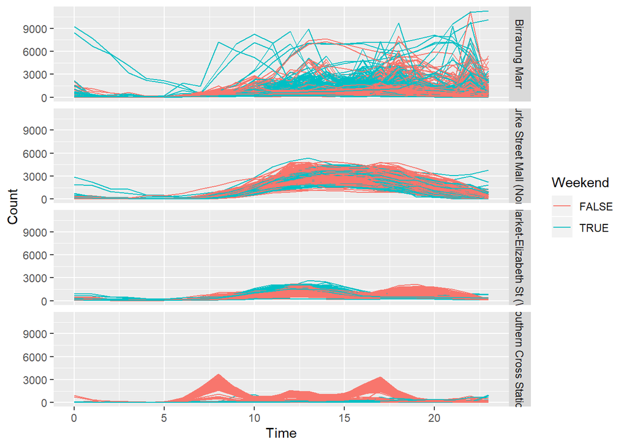

```r
pedestrian %>%
  mutate(
    Day = lubridate::wday(Date, label = TRUE),
    Weekend = (Day %in% c("周六", "周日"))
  ) %>%
  ggplot() +
  geom_line(aes(Time,Count,col = Weekend,group = Date)) +
  facet_grid(Sensor ~ .)
```